# Age-Period-Cohort

The identification problem

Lars Nørtoft Reiter

Age

changes over the life course of individuals

Biology

Risk aversion

Vitality

Political views

Period

changes due to the events in particular years

Technological disruption

Pandemics (e.g. Covid)

Recession

Cohort

changes due to the replacement of older cohorts of individuals with younger ones with different characteristics

Generation X *(1965 – 1980)*

Millenials *(1981 – 1996)*

Generation Z *(1997 – 2012)*

Generation Alpha *(2012 – 2020)*

$$\text{Age} = \text{Period} - \text{Cohort}$$

(Age = Calendar year – Birth year)

## The identification problem: linear effects

$$\text{Observation} = \beta_A\,\text{Age} + \beta_P\,\text{Period} + \beta_C\,\text{Cohort} + \text{Error}$$

$$\beta_A' = \beta_A + c \qquad \beta_P' = \beta_P - c \qquad \beta_C' = \beta_C + c$$

$$\begin{aligned}
\text{Observation} &= \beta_A'\,\text{Age} + \beta_P'\,\text{Period} + \beta_C'\,\text{Cohort} + \text{Error} \\
&= \beta_A\,\text{Age} + \beta_P\,\text{Period} + \beta_C\,\text{Cohort} + c\,(\text{Age} - \text{Period} + \text{Cohort}) + \text{Error} \\
&= \beta_A\,\text{Age} + \beta_P\,\text{Period} + \beta_C\,\text{Cohort} + \text{Error}
\end{aligned}$$

Example

Assume $\beta_A = \beta_P = \beta_C = 1$ and $c = -1$

*True model:* $\text{Observation} = 1 \cdot \text{Age} + 1 \cdot \text{Period} + 1 \cdot \text{Cohort} + \text{Error}$

*Fitted model:* $\text{Observation} = 2 \cdot \text{Period} + \text{Error}$

## The positive case

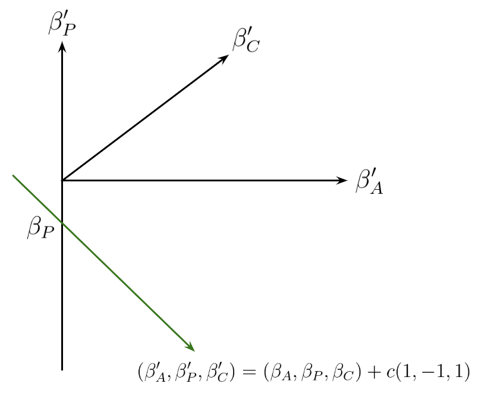

**Example (continued):**

Assume $\beta_A = \beta_P = \beta_C = 1$ and we know $\beta_P = 1$

Estimate $\beta_A' = \beta_C' = 0$ and $\beta_P' = 2$

$(0,\, 2,\, 0) = (\beta_A,\, 1,\, \beta_C) + c\,(1, -1, 1)$

## APC - how is it a problem

**Only linear effects are affected**

Discrete effects and non-linear variation still identifiable.

**No point estimates**

APC parameters are restricted to a *line of solutions*, once data is known.

**Mechanically unsolvable**

The APC identification problem cannot be solved without (strong) assumptions.

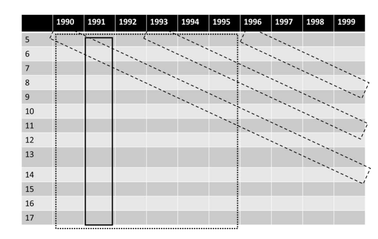

**APC in different study designs**

- **Cross-sectional** (solid): age ↔︎ cohort confounded
- **Single cohort** (dashed): age ↔︎ period confounded
- **Combined cohorts / cross-sectional** (dotted + all dashed): all of A, P, C vary — yet the linear problem remains

## ‘Solutions’: without assumptions

**Example: Line of solution**

Recall
$$\beta_A' = \beta_A + c \quad \beta_P' = \beta_P - c \quad \beta_C' = \beta_C + c$$

Individual change effect: $\quad \beta_A' + \beta_P' = \beta_A + \beta_P$

Cohort replacement effect: $\quad \beta_C' + \beta_P' = \beta_C + \beta_P$

**Limitation:** now identifiable, but confounds two effects. Risk misinterpretation.

**Example: Hierarchical APC**

Individuals (age) cross-classified within period and cohort random effects (Yang & Land).

**Limitation:** bias of the linear cohort effect towards zero.

Bell (2020), Annals of Human Biology.

## ‘Solutions’: with assumptions

Make the assumption explicit and theory-based.

**Example: Categorical APC**

Model A, P, C as categories.

This identifies the non-linear effects (curvature and discrete jumps) around possibly unknown linear trends.

**Limitation:** the linear trends stay unidentified.

**Example: Mechanism-based**

Replace one APC variable with the real driver behind it (e.g. swap cohort for a measure of medical technology).

That driver is not collinear with A, P, C, so identification is restored. Explain one dimension fully and the other two follow.

**Limitation:** you must know and measure the true mechanism. A partial or wrong driver can provide poor estimates.

Bell (2020), Annals of Human Biology.